# Fitting Bayesian LMMs using Stan: A tutorial

Shravan Vasishth and Tanner Sorensen

2015-06-13

```
##
##
## rstan (Version 2.6.0, packaged: 2015-02-06 21:02:34 UTC, GitRev: 198082f07a60)
```

# Example 1: Gibson and Wu 2013 data

This is the data reported in Gibson and Wu 2013. It is available with this package.

## Model 1

Read in the Read in the Gibson and Wu data:

```r
rDat<-read.table("../data/gibsonwu2012data.txt",header=TRUE)
```

Convert subject and item to factors:

```r
rDat$subj <- factor(rDat$subj)
rDat$item <- factor(rDat$item)
```

Apply sum contrast coding to predictor (obj:+1; subj:-1):

```r
rDat$so <- ifelse(rDat$type=="subj-ext",-1,1)
```

Set up data for Stan:

```r
stanDat<-list(rt=rDat$rt,
              so = rDat$so,
              N = nrow(rDat))
```

Load, compile, and fit model:

```r
fixEfFit <- stan(file="fixEf.stan",
                 data = stanDat,
                 iter=2000, chains = 4)
```

```
TRANSLATING MODEL 'fixEf' FROM Stan CODE TO C++ CODE NOW.
COMPILING THE C++ CODE FOR MODEL 'fixEf' NOW.


Iteration:    1 / 2000 [  0%]  (Warmup)
Iteration:  200 / 2000 [ 10%]  (Warmup)
Iteration:  400 / 2000 [ 20%]  (Warmup)
Iteration:  600 / 2000 [ 30%]  (Warmup)
Iteration:  800 / 2000 [ 40%]  (Warmup)
Iteration: 1000 / 2000 [ 50%]  (Warmup)
Iteration: 1001 / 2000 [ 50%]  (Sampling)
Iteration: 1200 / 2000 [ 60%]  (Sampling)
Iteration: 1400 / 2000 [ 70%]  (Sampling)
Iteration: 1600 / 2000 [ 80%]  (Sampling)
Iteration: 1800 / 2000 [ 90%]  (Sampling)
Iteration: 2000 / 2000 [100%]  (Sampling)
#  Elapsed Time: 1.15935 seconds (Warm-up)
#                1.07078 seconds (Sampling)
#                2.23013 seconds (Total)



Iteration:    1 / 2000 [  0%]  (Warmup)
Iteration:  200 / 2000 [ 10%]  (Warmup)
Iteration:  400 / 2000 [ 20%]  (Warmup)
Iteration:  600 / 2000 [ 30%]  (Warmup)
Iteration:  800 / 2000 [ 40%]  (Warmup)
Iteration: 1000 / 2000 [ 50%]  (Warmup)
Iteration: 1001 / 2000 [ 50%]  (Sampling)
Iteration: 1200 / 2000 [ 60%]  (Sampling)
Iteration: 1400 / 2000 [ 70%]  (Sampling)
Iteration: 1600 / 2000 [ 80%]  (Sampling)
Iteration: 1800 / 2000 [ 90%]  (Sampling)
Iteration: 2000 / 2000 [100%]  (Sampling)
#  Elapsed Time: 1.20911 seconds (Warm-up)
#                1.36155 seconds (Sampling)
#                2.57067 seconds (Total)



```

[output cut: 18 more lines]

```
Iteration:    1 / 2000 [  0%]  (Warmup)
Iteration:  200 / 2000 [ 10%]  (Warmup)
Iteration:  400 / 2000 [ 20%]  (Warmup)
Iteration:  600 / 2000 [ 30%]  (Warmup)
Iteration:  800 / 2000 [ 40%]  (Warmup)
Iteration: 1000 / 2000 [ 50%]  (Warmup)
Iteration: 1001 / 2000 [ 50%]  (Sampling)
Iteration: 1200 / 2000 [ 60%]  (Sampling)
Iteration: 1400 / 2000 [ 70%]  (Sampling)
Iteration: 1600 / 2000 [ 80%]  (Sampling)
Iteration: 1800 / 2000 [ 90%]  (Sampling)
Iteration: 2000 / 2000 [100%]  (Sampling)
#  Elapsed Time: 1.67094 seconds (Warm-up)
#                1.30092 seconds (Sampling)
#                2.97186 seconds (Total)
```

```r
save(list="fixEfFit",file="../data/fixEfFit.Rda",
     compress="xz")
```

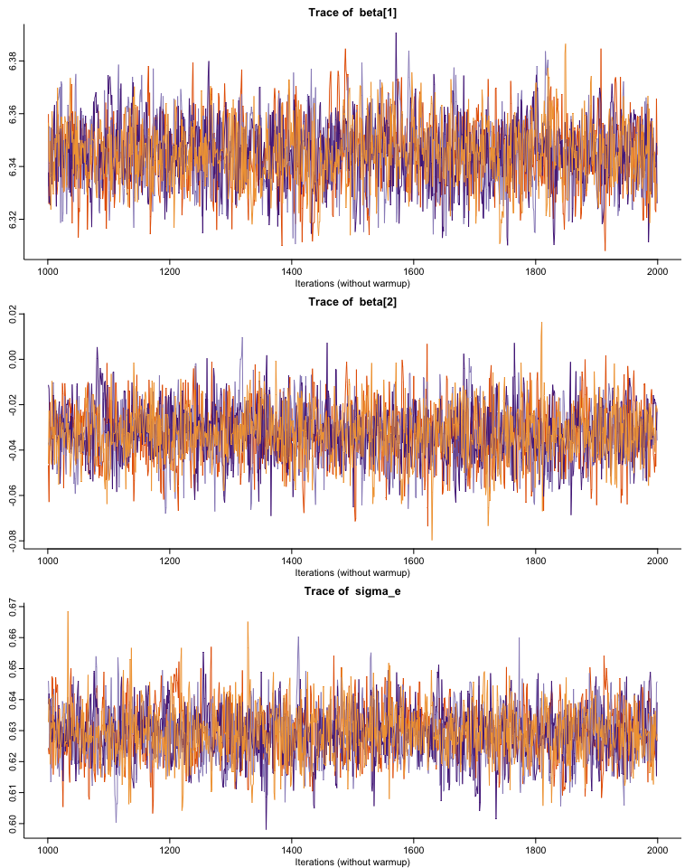

```r
traceplot(fixEfFit,pars=c("beta","sigma_e"),inc_warmup=FALSE)
```

```r
print(fixEfFit,pars=c("beta","sigma_e"),probs=c(0.025,0.5,0.975))
```

```
Inference for Stan model: fixEf.
4 chains, each with iter=2000; warmup=1000; thin=1;
post-warmup draws per chain=1000, total post-warmup draws=4000.

         mean se_mean   sd  2.5%   50% 97.5% n_eff Rhat
beta[1]  6.35       0 0.01  6.32  6.35  6.37  2278    1
beta[2] -0.03       0 0.01 -0.06 -0.03 -0.01  2154    1
sigma_e  0.63       0 0.01  0.61  0.63  0.65  2446    1

Samples were drawn using NUTS(diag_e) at Sat Jun 13 12:20:04 2015.
For each parameter, n_eff is a crude measure of effective sample size,
and Rhat is the potential scale reduction factor on split chains (at
convergence, Rhat=1).
```

Plot the posterior distributions:

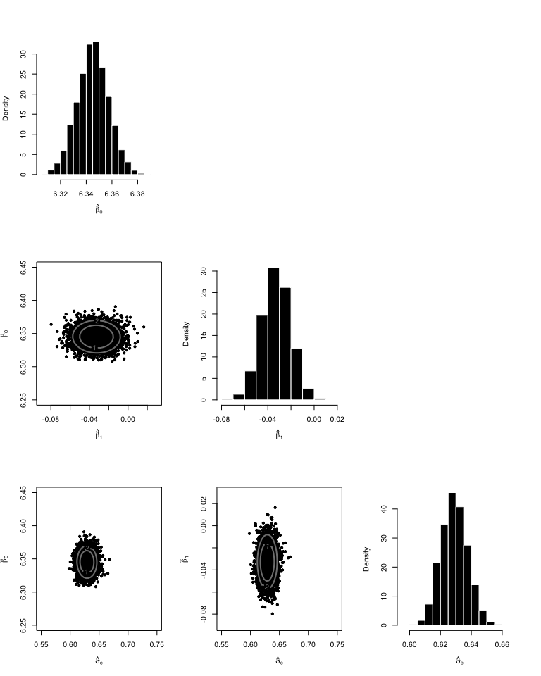

```r
beta0 <- extract(fixEfFit,pars=c("beta[1]"))$beta
beta1 <- extract(fixEfFit,pars=c("beta[2]"))$beta
sigma_e <- extract(fixEfFit,pars=c("sigma_e"))$sigma_e
N_iter<-length(beta0)
theta<-list(beta0=beta0,beta1=beta1,sigma_e=sigma_e)
lab<-c(expression(hat(beta)[0]),expression(hat(beta)[1]),expression(hat(sigma)[e]))
lim<-matrix(c(6.25,-0.09,.55,
              6.45,.03,.75),nrow=3,ncol=2)
par(mfrow=c(3,3))
for(i in 1:3)
  for(j in 1:3){
    if(i==j){
      # PLOT MARGINALS ON DIAGONAL
      hist(theta[[i]],freq=FALSE,col="black",border="white",main=NULL,xlab=lab[i])
    }else if(i>j){
      # PLOT BIVARIATE ON THE LOWER TRIANGULAR
      # CODE ADAPTED FROM:
      # http://stats.stackexchange.com/questions/24380/how-to-get-ellipse-region-from-bivariate-normal-distributed-data
      xy<-matrix(nrow=N_iter,ncol=2)
      xy[,1]<-theta[[i]]
      xy[,2]<-theta[[j]]
      center <- apply(xy, 2, mean)
      sigma <- cov(xy)
      sigma.inv = solve(sigma, matrix(c(1,0,0,1),2,2))
      # DEFINE GRID
      n <- 50
      xlim<-lim[i,]
      ylim<-lim[j,]
      x <- seq(xlim[1],xlim[2],length.out=n)
      y <- seq(ylim[1],ylim[2],length.out=n)
      # EVALUATE HEIGHT FUNCTION ON GRID
      height <- function(s,t) {u<-c(s,t)-center; u %*% sigma.inv %*% u / 2}
      z <- mapply(height, as.vector(rep(x,n)), as.vector(outer(rep(0,n), y, `+`)))
      # PLOT
      plot(xy, pch=20, xlim=xlim, ylim=ylim, xlab=lab[i], ylab=lab[j])
      contour(x,y,matrix(z,n,n), levels=(0:2), col = gray(.5), lwd=2, add=TRUE)
    }else{
      # SKIP UPPER TRIANGULAR PLOTS (REPEATS)
      plot.new()
    }
  }
```

Find the 95% credible interval for the slope parameter:

```r
beta1 <- extract(fixEfFit,pars=c("beta[2]"))$beta
print(signif(quantile(beta1,probs=c(0.025,0.5,0.975)),2))
```

```
   2.5%     50%   97.5%
-0.0570 -0.0330 -0.0091
```

## Model 2

$\log rt_{jk} = \beta _0 + u_{0j} + w_{0k} + \beta _1 so_{jk} + \epsilon_{jk}$

```r
stanDat<-list(subj=as.integer(factor(rDat$subj)),
              item=as.integer(factor(rDat$item)),
              rt=rDat$rt,
              so=rDat$so,
              N=nrow(rDat),
              J=length(unique(rDat$subj)),
              K=length(unique(rDat$item)))
```

```r
ranIntFit <- stan(file="ranInt.stan", data = stanDat,
                  iter=2000, chains = 4)
```

```
TRANSLATING MODEL 'ranInt' FROM Stan CODE TO C++ CODE NOW.
COMPILING THE C++ CODE FOR MODEL 'ranInt' NOW.


Iteration:    1 / 2000 [  0%]  (Warmup)
Iteration:  200 / 2000 [ 10%]  (Warmup)
Iteration:  400 / 2000 [ 20%]  (Warmup)
Iteration:  600 / 2000 [ 30%]  (Warmup)
Iteration:  800 / 2000 [ 40%]  (Warmup)
Iteration: 1000 / 2000 [ 50%]  (Warmup)
Iteration: 1001 / 2000 [ 50%]  (Sampling)
Iteration: 1200 / 2000 [ 60%]  (Sampling)
Iteration: 1400 / 2000 [ 70%]  (Sampling)
Iteration: 1600 / 2000 [ 80%]  (Sampling)
Iteration: 1800 / 2000 [ 90%]  (Sampling)
Iteration: 2000 / 2000 [100%]  (Sampling)
#  Elapsed Time: 6.96419 seconds (Warm-up)
#                6.10824 seconds (Sampling)
#                13.0724 seconds (Total)



Iteration:    1 / 2000 [  0%]  (Warmup)
Iteration:  200 / 2000 [ 10%]  (Warmup)
Iteration:  400 / 2000 [ 20%]  (Warmup)
Iteration:  600 / 2000 [ 30%]  (Warmup)
Iteration:  800 / 2000 [ 40%]  (Warmup)
Iteration: 1000 / 2000 [ 50%]  (Warmup)
Iteration: 1001 / 2000 [ 50%]  (Sampling)
Iteration: 1200 / 2000 [ 60%]  (Sampling)
Iteration: 1400 / 2000 [ 70%]  (Sampling)
Iteration: 1600 / 2000 [ 80%]  (Sampling)
Iteration: 1800 / 2000 [ 90%]  (Sampling)
Iteration: 2000 / 2000 [100%]  (Sampling)
#  Elapsed Time: 6.50451 seconds (Warm-up)
#                5.89695 seconds (Sampling)
#                12.4015 seconds (Total)



```

[output cut: 18 more lines]

```
Iteration:    1 / 2000 [  0%]  (Warmup)
Iteration:  200 / 2000 [ 10%]  (Warmup)
Iteration:  400 / 2000 [ 20%]  (Warmup)
Iteration:  600 / 2000 [ 30%]  (Warmup)
Iteration:  800 / 2000 [ 40%]  (Warmup)
Iteration: 1000 / 2000 [ 50%]  (Warmup)
Iteration: 1001 / 2000 [ 50%]  (Sampling)
Iteration: 1200 / 2000 [ 60%]  (Sampling)
Iteration: 1400 / 2000 [ 70%]  (Sampling)
Iteration: 1600 / 2000 [ 80%]  (Sampling)
Iteration: 1800 / 2000 [ 90%]  (Sampling)
Iteration: 2000 / 2000 [100%]  (Sampling)
#  Elapsed Time: 7.16463 seconds (Warm-up)
#                5.87446 seconds (Sampling)
#                13.0391 seconds (Total)
```

```r
save(list="ranIntFit",file="../data/ranIntFit.Rda",
     compress="xz")
```

## Model 3

$\log rt_{jk} = \beta_0 + u_{0j} + w_{0k} + (\beta_1 + u_{1j} + w_{1k}) so_{jk} + \epsilon_{jk}$

```r
############################
## VARYING INTERCEPTS,
## VARYING SLOPES MIXED
## EFFECTS MODEL
############################

# 1. Compile and fit model.
ranIntSlpFit <- stan(file="ranIntSlp.stan", data = stanDat,
                     iter=2000, chains = 4)
```

```
TRANSLATING MODEL 'ranIntSlp' FROM Stan CODE TO C++ CODE NOW.
COMPILING THE C++ CODE FOR MODEL 'ranIntSlp' NOW.


Iteration:    1 / 2000 [  0%]  (Warmup)
Iteration:  200 / 2000 [ 10%]  (Warmup)
Iteration:  400 / 2000 [ 20%]  (Warmup)
Iteration:  600 / 2000 [ 30%]  (Warmup)
Iteration:  800 / 2000 [ 40%]  (Warmup)
Iteration: 1000 / 2000 [ 50%]  (Warmup)
Iteration: 1001 / 2000 [ 50%]  (Sampling)
Iteration: 1200 / 2000 [ 60%]  (Sampling)
Iteration: 1400 / 2000 [ 70%]  (Sampling)
Iteration: 1600 / 2000 [ 80%]  (Sampling)
Iteration: 1800 / 2000 [ 90%]  (Sampling)
Iteration: 2000 / 2000 [100%]  (Sampling)
#  Elapsed Time: 25.9373 seconds (Warm-up)
#                12.2993 seconds (Sampling)
#                38.2367 seconds (Total)



Iteration:    1 / 2000 [  0%]  (Warmup)
Iteration:  200 / 2000 [ 10%]  (Warmup)
Iteration:  400 / 2000 [ 20%]  (Warmup)
Iteration:  600 / 2000 [ 30%]  (Warmup)
Iteration:  800 / 2000 [ 40%]  (Warmup)
Iteration: 1000 / 2000 [ 50%]  (Warmup)
Iteration: 1001 / 2000 [ 50%]  (Sampling)
Iteration: 1200 / 2000 [ 60%]  (Sampling)
Iteration: 1400 / 2000 [ 70%]  (Sampling)
Iteration: 1600 / 2000 [ 80%]  (Sampling)
Iteration: 1800 / 2000 [ 90%]  (Sampling)
Iteration: 2000 / 2000 [100%]  (Sampling)
#  Elapsed Time: 27.8808 seconds (Warm-up)
#                14.4623 seconds (Sampling)
#                42.343 seconds (Total)



```

[output cut: 18 more lines]

```
Iteration:    1 / 2000 [  0%]  (Warmup)
Iteration:  200 / 2000 [ 10%]  (Warmup)
Iteration:  400 / 2000 [ 20%]  (Warmup)
Iteration:  600 / 2000 [ 30%]  (Warmup)
Iteration:  800 / 2000 [ 40%]  (Warmup)
Iteration: 1000 / 2000 [ 50%]  (Warmup)
Iteration: 1001 / 2000 [ 50%]  (Sampling)
Iteration: 1200 / 2000 [ 60%]  (Sampling)
Iteration: 1400 / 2000 [ 70%]  (Sampling)
Iteration: 1600 / 2000 [ 80%]  (Sampling)
Iteration: 1800 / 2000 [ 90%]  (Sampling)
Iteration: 2000 / 2000 [100%]  (Sampling)
#  Elapsed Time: 27.2174 seconds (Warm-up)
#                14.4983 seconds (Sampling)
#                41.7157 seconds (Total)
```

```r
save(list="ranIntSlpFit",
     file="../data/ranIntSlpFit.Rda",
     compress="xz")
```

## Posterior predictive checks

```r
############################
## POSTERIOR PREDICTIVE
## CHECKS
############################

# 1. Compile and fit model.
pp <- stan(file="pp.stan", data = stanDat,
           warmup=500,iter=750, chains = 1)
```

```
TRANSLATING MODEL 'pp' FROM Stan CODE TO C++ CODE NOW.
COMPILING THE C++ CODE FOR MODEL 'pp' NOW.


Iteration:   1 / 750 [  0%]  (Warmup)
Iteration:  75 / 750 [ 10%]  (Warmup)
Iteration: 150 / 750 [ 20%]  (Warmup)
Iteration: 225 / 750 [ 30%]  (Warmup)
Iteration: 300 / 750 [ 40%]  (Warmup)
Iteration: 375 / 750 [ 50%]  (Warmup)
Iteration: 450 / 750 [ 60%]  (Warmup)
Iteration: 501 / 750 [ 66%]  (Sampling)
Iteration: 575 / 750 [ 76%]  (Sampling)
Iteration: 650 / 750 [ 86%]  (Sampling)
Iteration: 725 / 750 [ 96%]  (Sampling)
Iteration: 750 / 750 [100%]  (Sampling)
#  Elapsed Time: 26.2619 seconds (Warm-up)
#                3.54511 seconds (Sampling)
#                29.807 seconds (Total)
```

```r
save(list="pp",file="../data/pp.Rda",
     compress="xz")
```

Plot correlations between intercepts and slopes for subjects and for items:

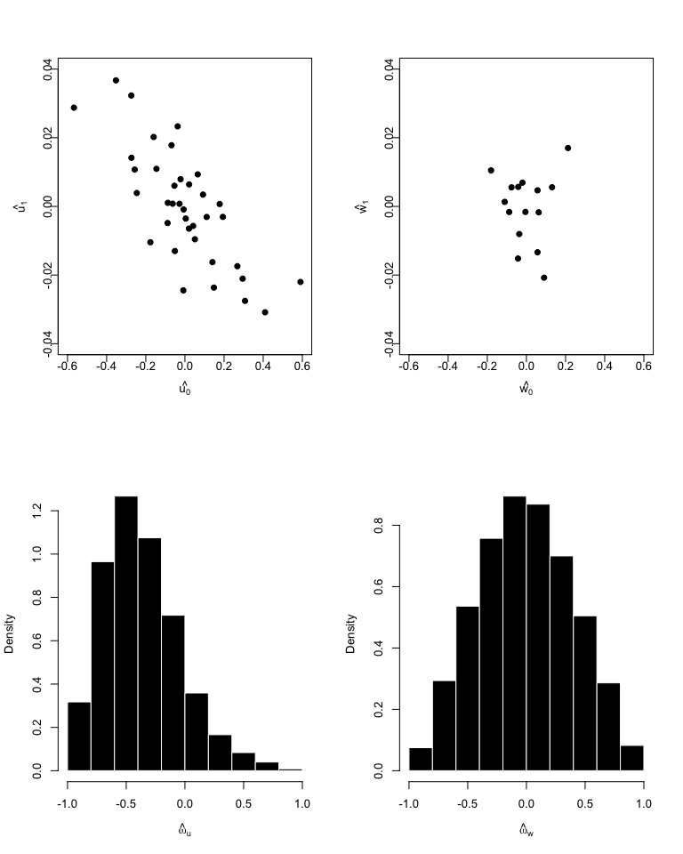

```r
J<-length(unique(rDat$subj))
u<-matrix(nrow=2,ncol=J)
for(j in 1:J)
  for(i in 1:2)
    u[i,j]<-mean(extract(ranIntSlpFit,pars=c(paste("u[",i,",",j,"]",sep="")))[[1]])
N_sample<-length(extract(ranIntSlpFit,pars="L_u[1,1]")[[1]])
L_u<-array(dim=c(2,2,N_sample))
for(i in 1:2)
  for(j in 1:2)
    L_u[i,j,]<-extract(ranIntSlpFit,pars=c(paste("L_u[",i,",",j,"]",sep="")))[[1]]
omega_u<-numeric()
for(i in 1:N_sample){
  Omega_u<-L_u[,,i]%*%t(L_u[,,i])
  omega_u[i]<-Omega_u[1,2]
}
# Extract item random intercepts and slopes.
K<-length(unique(rDat$item))
w<-matrix(nrow=2,ncol=K)
for(k in 1:K)
  for(i in 1:2)
    w[i,k]<-mean(extract(ranIntSlpFit,pars=c(paste("w[",i,",",k,"]",sep="")))[[1]])
L_w<-array(dim=c(2,2,N_sample))
for(i in 1:2)
  for(j in 1:2)
    L_w[i,j,]<-extract(ranIntSlpFit,pars=c(paste("L_w[",i,",",j,"]",sep="")))[[1]]
omega_w<-numeric()
for(i in 1:N_sample){
  Omega_w<-L_w[,,i]%*%t(L_w[,,i])
  omega_w[i]<-Omega_w[1,2]
}
# Visualize the posterior distribution for the intercept beta[1] ...
par(mfrow=c(2,2),pch=21,bg="white")
plot(u[1,],u[2,],bg="black",mgp=c(2,.25,0),
     xlim=c(-.6,.6),ylim=c(-.04,.04),
     xlab=expression(hat(u[0])),ylab=expression(hat(u[1])))
plot(w[1,],w[2,],bg="black",mgp=c(2,.25,0),
     xlim=c(-.6,.6),ylim=c(-.04,.04),
     xlab=expression(hat(w[0])),ylab=expression(hat(w[1])))
hist(omega_u,freq=FALSE,col="black",border="white",
     main=NULL,xlab=expression(hat(omega)[u]))
hist(omega_w,freq=FALSE,col="black",border="white",
     main=NULL,xlab=expression(hat(omega)[w]))
```

Inference:

```r
library(coda)
```

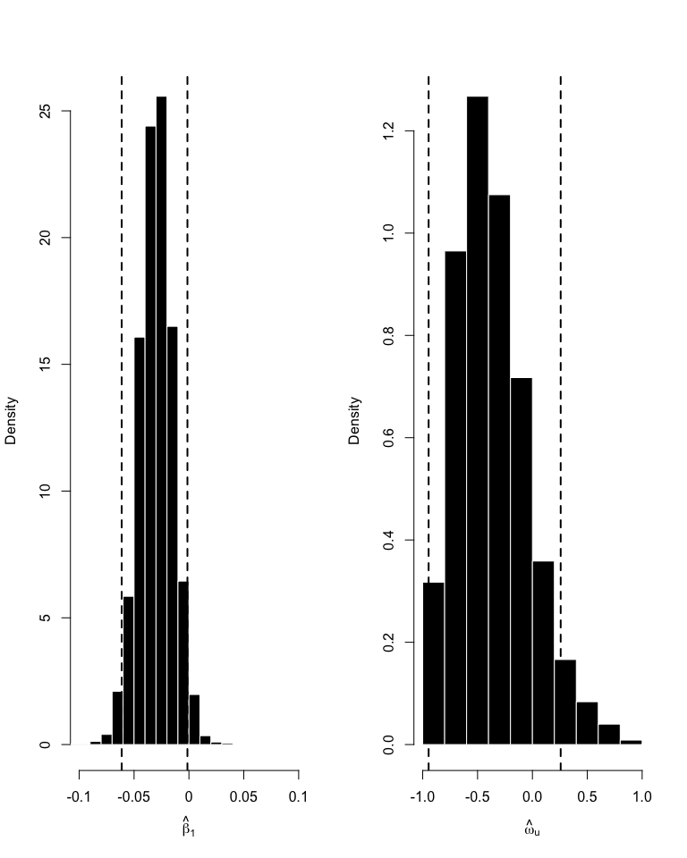

```r
# Get HPD interval for beta[2]
beta1<-as.mcmc(unlist(extract(ranIntSlpFit,pars="beta[2]")))
betaHPD<-HPDinterval(beta1,prob=0.95)
# Get HPD interval for omega_u
N_iter<-length(beta1)
omega_u<-numeric(N_iter)
L_u<-array(dim=c(2,2,N_iter))
for(i in 1:2)
  for(j in 1:2)
    L_u[i,j,]<-extract(ranIntSlpFit,pars=paste("L_u[",i,",",j,"]",sep=""))[[1]]
for(i in 1:N_iter)
  omega_u[i] <- tcrossprod(L_u[,,i])[1,2]
omega_u<-as.mcmc(omega_u)
omegaHPD<-HPDinterval(omega_u,prob=0.95)
# PLOT HPD INTERVALS ON THE MARGINAL POSTERIORS
par(mfrow=c(1,2))
hist(beta1,freq=FALSE,col="black",border="white",xaxt="n",
     main=NULL,xlim=c(-.1,.1),xlab=expression(hat(beta)[1]))
abline(v=betaHPD,lty=2,lwd=2)
axis(1, at = seq(-.1,.1,length.out=5), labels = seq(-.1,.1,length.out=5))
hist(omega_u,freq=FALSE,col="black",border="white",
     main=NULL,xlab=expression(hat(omega)[u]),xlim=c(-1,1))
abline(v=omegaHPD,lty=2,lwd=2)
```

Posterior predictive checks:

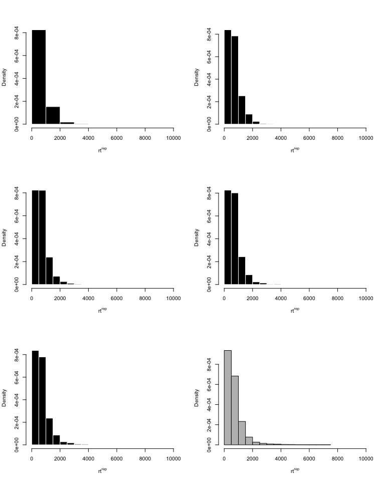

```r
rDat<-read.table("../data/gibsonwu2012data.txt",header=TRUE)
# 2. Define the test quantity.
test<-function(rt){quantile(rt,probs=.95,names=FALSE)}
# 3. Get maximum of observed RT distribution.
upRT <- test(rDat$rt)
# 4. Read in the posterior predictive model.
load("../data/pp.Rda")
# 5. Extract the posterior predictive RT distributions.
# (rows are data-sets, columns are trials)
rt_tilde<-extract(pp,pars="rt_tilde")[[1]]
# 6. compare 5 randomly selected posterior predictive
# RT distributions to the observed RT distribution.
par(mfrow=c(3,2))
for(i in sample(1:dim(rt_tilde)[1],5,replace=FALSE,prob=NULL))
  hist(rt_tilde[i,],freq=FALSE,col="black",border="white",
     main=NULL,xlab=expression(rt^{rep}),xlim=c(0,1E4))
hist(rDat$rt,freq=FALSE,col="gray",border="black",
     main=NULL,xlab=expression(rt^{rep}),xlim=c(0,1E4))
```

Distribution of the test statistic:

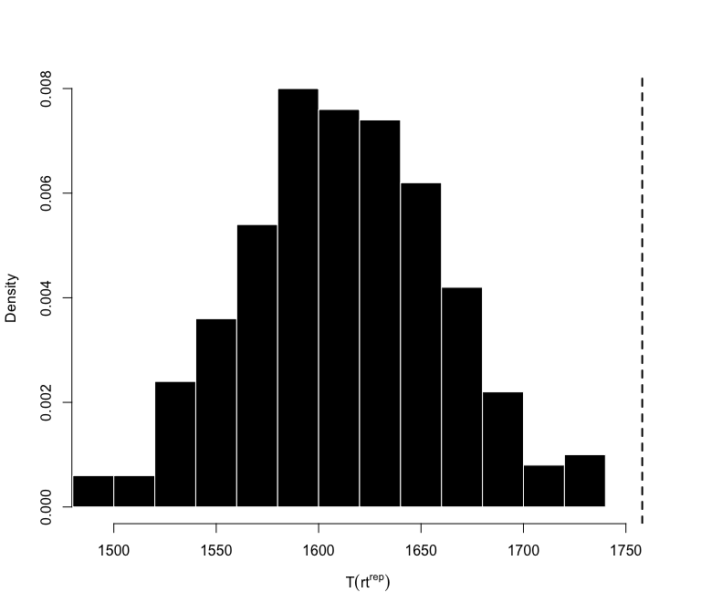

```r
upRTrep<-apply(rt_tilde, 1, test)
# 8. Compute the probability that upRTrep is greater
# than the maximum of the observed RT distribution.
p<-mean(upRTrep>upRT)
# 9. Plot the posterior predictive test quantities
# upRTrep and the observed test quantity upRT.
hist(upRTrep,freq=FALSE,col="black",border="white",
     main=NULL,xlab=expression(T(rt^{rep})),xlim=c(min(upRTrep),upRT))
abline(v=upRT,lty=2,lwd=2)
```

## Model 6: 2x2 factorial design

This is an analysis of the data reported in Husain et al 2014. It is included with this package.

```r
############################
## FACTORIAL MODEL
############################

# 1. Read in the Husain et al. data.
rDat<-read.table("../data/HusainEtAlexpt1data.txt",header=TRUE)
rDat$so<-rDat$RCType # Change name for consistency.
# 2. Make design matrix.
X <- unname(model.matrix(~ 1+so+dist+int, rDat))
attr(X,"assign") <- NULL
# 3. Factor subj and item.
rDat$subj <- with(rDat,factor(subj))
rDat$item <- with(rDat,factor(item))
# 4. Make Stan data.
stanDat <- within(list(),
{
  N<-nrow(X)
  P <- n_u <- n_w <- ncol(X)
  X <- Z_u <- Z_w <- X
  J <- length(levels(rDat$subj))
  K <- length(levels(rDat$item))
  rt <- rDat$rt
  subj <- as.integer(rDat$subj)
  item <- as.integer(rDat$item)
}
)
# 5. Fit the model.
factorialFit <- stan(file="factorialModel.stan",data=stanDat,
                     iter=2000, chains=4)
```

```
TRANSLATING MODEL 'factorialModel' FROM Stan CODE TO C++ CODE NOW.
COMPILING THE C++ CODE FOR MODEL 'factorialModel' NOW.


Iteration:    1 / 2000 [  0%]  (Warmup)
Iteration:  200 / 2000 [ 10%]  (Warmup)
Iteration:  400 / 2000 [ 20%]  (Warmup)
Iteration:  600 / 2000 [ 30%]  (Warmup)
Iteration:  800 / 2000 [ 40%]  (Warmup)
Iteration: 1000 / 2000 [ 50%]  (Warmup)
Iteration: 1001 / 2000 [ 50%]  (Sampling)
Iteration: 1200 / 2000 [ 60%]  (Sampling)
Iteration: 1400 / 2000 [ 70%]  (Sampling)
Iteration: 1600 / 2000 [ 80%]  (Sampling)
Iteration: 1800 / 2000 [ 90%]  (Sampling)
Iteration: 2000 / 2000 [100%]  (Sampling)
#  Elapsed Time: 73.6592 seconds (Warm-up)
#                31.5614 seconds (Sampling)
#                105.221 seconds (Total)



Iteration:    1 / 2000 [  0%]  (Warmup)
Iteration:  200 / 2000 [ 10%]  (Warmup)
Iteration:  400 / 2000 [ 20%]  (Warmup)
Iteration:  600 / 2000 [ 30%]  (Warmup)
Iteration:  800 / 2000 [ 40%]  (Warmup)
Iteration: 1000 / 2000 [ 50%]  (Warmup)
Iteration: 1001 / 2000 [ 50%]  (Sampling)
Iteration: 1200 / 2000 [ 60%]  (Sampling)
Iteration: 1400 / 2000 [ 70%]  (Sampling)
Iteration: 1600 / 2000 [ 80%]  (Sampling)
Iteration: 1800 / 2000 [ 90%]  (Sampling)
Iteration: 2000 / 2000 [100%]  (Sampling)
#  Elapsed Time: 84.6755 seconds (Warm-up)
#                39.9821 seconds (Sampling)
#                124.658 seconds (Total)



```

[output cut: 18 more lines]

```
Iteration:    1 / 2000 [  0%]  (Warmup)
Iteration:  200 / 2000 [ 10%]  (Warmup)
Iteration:  400 / 2000 [ 20%]  (Warmup)
Iteration:  600 / 2000 [ 30%]  (Warmup)
Iteration:  800 / 2000 [ 40%]  (Warmup)
Iteration: 1000 / 2000 [ 50%]  (Warmup)
Iteration: 1001 / 2000 [ 50%]  (Sampling)
Iteration: 1200 / 2000 [ 60%]  (Sampling)
Iteration: 1400 / 2000 [ 70%]  (Sampling)
Iteration: 1600 / 2000 [ 80%]  (Sampling)
Iteration: 1800 / 2000 [ 90%]  (Sampling)
Iteration: 2000 / 2000 [100%]  (Sampling)
#  Elapsed Time: 73.0344 seconds (Warm-up)
#                41.117 seconds (Sampling)
#                114.151 seconds (Total)
```

```r
# 6. Save the result.
save(list="factorialFit",
     file="../data/factorialFit.Rda",
     compress="xz")
```

$\log rt_{jk} = \beta _0 + u_{0j} + w_{0k} &+(\beta _1 +u_{1j} +w_{1k})so_{jk} &+(\beta _2 +u_{2j} +w_{2k})dist_{jk} &+(\beta _3 +u_{3j} +w_{3k})int_{jk} + \epsilon_{jk}$

In matrix form:

$\mathrm{rt} = X\beta + Z_j u_j + Z_k w_k + \epsilon$

$X$ is the $N\times P$ model matrix (with P=4 since we have three fixed effects, plus the intercept), $\beta$ is a $P\times 1$ vector of fixed effects parameters, $Z_j$ and $Z_k$ are the subject and item model matrices ($N\times P$), and $u_j$ and $w_k$ are the by-subject and by-item adjustments to the fixed effects estimates. $\epsilon$ refers to the residual error ($N\times 1$).

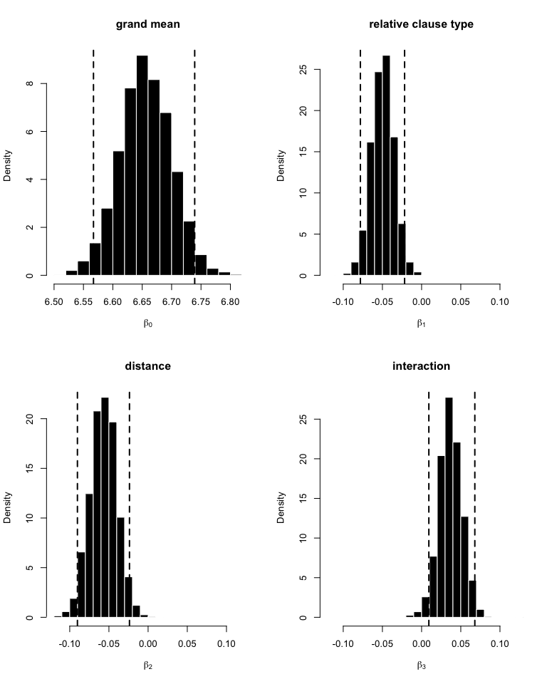

```r
# Extract the fixef coefs.
beta0 <- extract(factorialFit,pars=c("beta[1]"))
beta1 <- extract(factorialFit,pars=c("beta[2]"))
beta2 <- extract(factorialFit,pars=c("beta[3]"))
beta3 <- extract(factorialFit,pars=c("beta[4]"))
# Get HPD interval for the fixef coefs.
beta0HPD<-HPDinterval(as.mcmc(unlist(beta0)),prob=0.95)
beta1HPD<-HPDinterval(as.mcmc(unlist(beta1)),prob=0.95)
beta2HPD<-HPDinterval(as.mcmc(unlist(beta2)),prob=0.95)
beta3HPD<-HPDinterval(as.mcmc(unlist(beta3)),prob=0.95)
# Plot histograms with HPDs as dotted lines
par(mfrow=c(2,2))
hist(beta0$beta,freq=FALSE,col="black",border="white",main="grand mean",xlab=expression(beta[0]))
abline(v=beta0HPD,lty=2,lwd=2)
hist(beta1$beta,freq=FALSE,col="black",border="white",main="relative clause type",
     xlim=c(-.12,.12),xlab=expression(beta[1]))
abline(v=beta1HPD,lty=2,lwd=2)
hist(beta2$beta,freq=FALSE,col="black",border="white",main="distance",
     xlim=c(-.12,.12),xlab=expression(beta[2]))
abline(v=beta2HPD,lty=2,lwd=2)
hist(beta3$beta,freq=FALSE,col="black",border="white",main="interaction",
     xlim=c(-.12,.12),xlab=expression(beta[3]))
abline(v=beta3HPD,lty=2,lwd=2)
```